# 2014 Gag Assessment Update - Commercial Length and Age Composition

**Length Composition** The SEDAR 10 gag data workshop developed commercial length compostions for handline, longline, trawl, and diving gear. The contribution of each length was weighted by the landings in number associated by state and year. The minimal longline and trawl compositions were combined with handline using sample size as a weighting factor.

The 2014 gag update assessment uses a slightly modified approach. For each gear, state-specific length compositions were developed and then multiplied by the relative contibution of that state's landings to the total Southeast commercial landings. The weighting unit was pounds instead of numbers to 1) elimate the need to convert using mean weights, and 2) allow use of the unit in which the data were collected.

The 2010 shallow water spawning closure eliminated collections of lengths for January-April for all areas. The lack of length data for these months in recent years is not accounted for in the length compositions.

## Tables

**Table 1.** Commercial Handline sample size by state (number of fish).

|  | NC | SC | GAFL | Total |
| --- | --- | --- | --- | --- |
| 1983 | 116 | 0 | 0 | 116 |
| 1984 | 1549 | 1701 | 20 | 3270 |
| 1985 | 1155 | 1771 | 702 | 3628 |
| 1986 | 1231 | 856 | 211 | 2298 |
| 1987 | 1193 | 1940 | 243 | 3376 |
| 1988 | 878 | 871 | 183 | 1932 |
| 1989 | 710 | 851 | 191 | 1752 |
| 1990 | 570 | 583 | 152 | 1305 |
| 1991 | 581 | 569 | 346 | 1496 |
| 1992 | 385 | 766 | 1046 | 2197 |
| 1993 | 389 | 1060 | 1079 | 2528 |
| 1994 | 613 | 902 | 383 | 1898 |
| 1995 | 658 | 1066 | 1485 | 3209 |
| 1996 | 226 | 1462 | 727 | 2415 |
| 1997 | 146 | 1329 | 506 | 1981 |
| 1998 | 142 | 1776 | 317 | 2235 |
| 1999 | 300 | 1612 | 569 | 2481 |
| 2000 | 388 | 1360 | 685 | 2433 |
| 2001 | 443 | 1276 | 493 | 2212 |
| 2002 | 356 | 910 | 248 | 1514 |
| 2003 | 356 | 1293 | 273 | 1922 |
| 2004 | 1034 | 976 | 167 | 2177 |
| 2005 | 1241 | 920 | 80 | 2241 |
| 2006 | 1138 | 616 | 110 | 1864 |
| 2007 | 1068 | 676 | 170 | 1914 |
| 2008 | 688 | 859 | 39 | 1586 |
| 2009 | 504 | 790 | 64 | 1358 |
| 2010 | 542 | 439 | 4 | 985 |
| 2011 | 636 | 445 | 17 | 1098 |
| 2012 | 805 | 230 | 15 | 1050 |

**Table 2.** Commercial Diving sample size by state (number of fish).

|  | NC | SC | GAFL | Total |
| --- | --- | --- | --- | --- |
| 1987 | 0 | 11 | 0 | 11 |
| 1991 | 0 | 0 | 3 | 3 |
| 1992 | 0 | 30 | 37 | 67 |
| 1993 | 0 | 0 | 65 | 65 |
| 1994 | 0 | 0 | 122 | 122 |
| 1995 | 0 | 0 | 126 | 126 |
| 1996 | 0 | 65 | 57 | 122 |
| 1997 | 0 | 0 | 121 | 121 |
| 1998 | 0 | 0 | 12 | 12 |
| 1999 | 0 | 0 | 348 | 348 |
| 2000 | 0 | 0 | 224 | 224 |
| 2001 | 0 | 0 | 147 | 147 |
| 2002 | 0 | 0 | 58 | 58 |
| 2003 | 0 | 0 | 497 | 497 |
| 2004 | 0 | 24 | 0 | 24 |
| 2005 | 0 | 11 | 10 | 21 |
| 2006 | 0 | 12 | 23 | 35 |
| 2007 | 0 | 0 | 14 | 14 |
| 2008 | 0 | 11 | 52 | 63 |
| 2009 | 0 | 23 | 2 | 25 |
| 2010 | 39 | 101 | 6 | 146 |
| 2011 | 12 | 58 | 9 | 79 |
| 2012 | 0 | 0 | 1 | 1 |

**Table 3.** Commercial handline weighted length composition (n=number of fish, years with 100 or more fish).

|  | n | 29 | 32 | 35 | 38 | 41 | 44 | 47 | 50 | 53 | 56 | 59 | 62 | 65 | 68 | 71 | 74 | 77 | 80 | 83 | 86 | 89 | 92 | 95 | 98 | 101 | 104 | 107 | 110 | … |
| --- | --- | --- | --- | --- | --- | --- | --- | --- | --- | --- | --- | --- | --- | --- | --- | --- | --- | --- | --- | --- | --- | --- | --- | --- | --- | --- | --- | --- | --- | --- |
| 1983 | 116 | 0.0000000 | 0.0000000 | 0.0000000 | 0.0086207 | 0.0086207 | 0.0258621 | 0.0344828 | 0.0086207 | 0.0172414 | 0.0431034 | 0.0517241 | 0.0431034 | 0.0431034 | 0.0431034 | 0.0603448 | 0.0689655 | 0.1034483 | 0.0689655 | 0.0775862 | 0.0517241 | 0.0603448 | 0.0344828 | 0.0344828 | 0.0172414 | 0.0344828 | 0.0431034 | 0.0086207 | 0.0000000 | … |
| 1984 | 3270 | 0.0000000 | 0.0004173 | 0.0000000 | 0.0010108 | 0.0016368 | 0.0026477 | 0.0065474 | 0.0119864 | 0.0133306 | 0.0159132 | 0.0152033 | 0.0382278 | 0.0381545 | 0.0268509 | 0.0280379 | 0.0554906 | 0.0435096 | 0.1242851 | 0.1151172 | 0.0936592 | 0.0998111 | 0.1095618 | 0.0288460 | 0.0248351 | 0.0493582 | 0.0212848 | 0.0162685 | 0.0114987 | … |
| 1985 | 3628 | 0.0003098 | 0.0012391 | 0.0034076 | 0.0021685 | 0.0026493 | 0.0033385 | 0.0030236 | 0.0036482 | 0.0058465 | 0.0086744 | 0.0131752 | 0.0163502 | 0.0226013 | 0.0250497 | 0.0333159 | 0.0386220 | 0.0584055 | 0.0751007 | 0.0898338 | 0.0945872 | 0.0913199 | 0.0844306 | 0.0757997 | 0.0626143 | 0.0633872 | 0.0478438 | 0.0318766 | 0.0256850 | … |
| 1986 | 2298 | 0.0015827 | 0.0047582 | 0.0050869 | 0.0054055 | 0.0105040 | 0.0193948 | 0.0257256 | 0.0358994 | 0.0245251 | 0.0305342 | 0.0289875 | 0.0404413 | 0.0455006 | 0.0420555 | 0.0433497 | 0.0550764 | 0.0592752 | 0.0599120 | 0.0770045 | 0.0719299 | 0.0486848 | 0.0547254 | 0.0502872 | 0.0375797 | 0.0442249 | 0.0314730 | 0.0270018 | 0.0127218 | … |
| 1987 | 3376 | 0.0002745 | 0.0008234 | 0.0010978 | 0.0057287 | 0.0057635 | 0.0112178 | 0.0134625 | 0.0196711 | 0.0198736 | 0.0232047 | 0.0253863 | 0.0265214 | 0.0273219 | 0.0312603 | 0.0461535 | 0.0608417 | 0.0775252 | 0.1070248 | 0.1109696 | 0.0919757 | 0.0614372 | 0.0474821 | 0.0366612 | 0.0360615 | 0.0325868 | 0.0348421 | 0.0163819 | 0.0127759 | … |
| 1988 | 1932 | 0.0000000 | 0.0000000 | 0.0000000 | 0.0013209 | 0.0051130 | 0.0040273 | 0.0101446 | 0.0138432 | 0.0183288 | 0.0139835 | 0.0202771 | 0.0199795 | 0.0274536 | 0.0266678 | 0.0376809 | 0.0494306 | 0.0859825 | 0.1173374 | 0.1215614 | 0.1032915 | 0.0750174 | 0.0486640 | 0.0455832 | 0.0407701 | 0.0311930 | 0.0235786 | 0.0241952 | 0.0220694 | … |
| 1989 | 1752 | 0.0000000 | 0.0004368 | 0.0004368 | 0.0008736 | 0.0028947 | 0.0037684 | 0.0046420 | 0.0103749 | 0.0134349 | 0.0113051 | 0.0105401 | 0.0206878 | 0.0309563 | 0.0411679 | 0.0772820 | 0.1004151 | 0.1034137 | 0.1068513 | 0.1005308 | 0.0825208 | 0.0670013 | 0.0566504 | 0.0420977 | 0.0425249 | 0.0173067 | 0.0158237 | 0.0138617 | 0.0098195 | … |
| 1990 | 1305 | 0.0000000 | 0.0004659 | 0.0024312 | 0.0010336 | 0.0010336 | 0.0043383 | 0.0109624 | 0.0104965 | 0.0160287 | 0.0132335 | 0.0224535 | 0.0221722 | 0.0333384 | 0.0467314 | 0.0515503 | 0.0801846 | 0.0997013 | 0.1055827 | 0.1158787 | 0.0824787 | 0.0663436 | 0.0442163 | 0.0344477 | 0.0288969 | 0.0345746 | 0.0298140 | 0.0168048 | 0.0187067 | … |
| 1991 | 1496 | 0.0000000 | 0.0000000 | 0.0000000 | 0.0011764 | 0.0025637 | 0.0075989 | 0.0093845 | 0.0208387 | 0.0262460 | 0.0238701 | 0.0215403 | 0.0301245 | 0.0239854 | 0.0472460 | 0.0520933 | 0.0588195 | 0.0917253 | 0.1438517 | 0.1176091 | 0.0830821 | 0.0751571 | 0.0382246 | 0.0379907 | 0.0247011 | 0.0262532 | 0.0162784 | 0.0073154 | 0.0079974 | … |
| 1992 | 2197 | 0.0000000 | 0.0000000 | 0.0000000 | 0.0000000 | 0.0000000 | 0.0019531 | 0.0073026 | 0.0257286 | 0.0500798 | 0.0470785 | 0.0521558 | 0.0537220 | 0.0529795 | 0.0488781 | 0.0460494 | 0.0457271 | 0.0927251 | 0.1161930 | 0.1249787 | 0.0704678 | 0.0553363 | 0.0344768 | 0.0181348 | 0.0153270 | 0.0131846 | 0.0090498 | 0.0099004 | 0.0053391 | … |
| 1993 | 2528 | 0.0000000 | 0.0000000 | 0.0002833 | 0.0000000 | 0.0002833 | 0.0006844 | 0.0056154 | 0.0215094 | 0.0389990 | 0.0464547 | 0.0555777 | 0.0579455 | 0.0582370 | 0.0659134 | 0.0626100 | 0.0680797 | 0.0605199 | 0.0893894 | 0.0867281 | 0.0792810 | 0.0631965 | 0.0346854 | 0.0295489 | 0.0238207 | 0.0157658 | 0.0139636 | 0.0111385 | 0.0055931 | … |
| 1994 | 1898 | 0.0000000 | 0.0000000 | 0.0000000 | 0.0000000 | 0.0000000 | 0.0006022 | 0.0080074 | 0.0177370 | 0.0312392 | 0.0415930 | 0.0428712 | 0.0567916 | 0.0674376 | 0.0741280 | 0.0772607 | 0.0921933 | 0.0954364 | 0.1000761 | 0.0797062 | 0.0618100 | 0.0410312 | 0.0286837 | 0.0230346 | 0.0205778 | 0.0153079 | 0.0106691 | 0.0076281 | 0.0043192 | … |
| 1995 | 3209 | 0.0000000 | 0.0000000 | 0.0000000 | 0.0000000 | 0.0000000 | 0.0000000 | 0.0003855 | 0.0108344 | 0.0224688 | 0.0291964 | 0.0164085 | 0.0256880 | 0.0400207 | 0.0425846 | 0.0634275 | 0.0659888 | 0.0885203 | 0.1176901 | 0.1214313 | 0.0938590 | 0.0818288 | 0.0510678 | 0.0316769 | 0.0221397 | 0.0220893 | 0.0195813 | 0.0146597 | 0.0092488 | … |
| 1996 | 2415 | 0.0000000 | 0.0009212 | 0.0000000 | 0.0004606 | 0.0000000 | 0.0013818 | 0.0036849 | 0.0065781 | 0.0195063 | 0.0333069 | 0.0276204 | 0.0387818 | 0.0205502 | 0.0319288 | 0.0391302 | 0.0611217 | 0.0720903 | 0.1350355 | 0.1324265 | 0.1055119 | 0.0720980 | 0.0500591 | 0.0405930 | 0.0348905 | 0.0215066 | 0.0182351 | 0.0109180 | 0.0115012 | … |
| 1997 | 1981 | 0.0000000 | 0.0000000 | 0.0000000 | 0.0000000 | 0.0000000 | 0.0000000 | 0.0000000 | 0.0152485 | 0.0163221 | 0.0248974 | 0.0342598 | 0.0589336 | 0.0486630 | 0.0467998 | 0.0411639 | 0.0499990 | 0.0952464 | 0.0993270 | 0.1112598 | 0.0903671 | 0.0663343 | 0.0495600 | 0.0414612 | 0.0209652 | 0.0333214 | 0.0183946 | 0.0138228 | 0.0069392 | … |
| 1998 | 2235 | 0.0000000 | 0.0000000 | 0.0000000 | 0.0000000 | 0.0000000 | 0.0021441 | 0.0012491 | 0.0154430 | 0.0200852 | 0.0299314 | 0.0332376 | 0.0293905 | 0.0402452 | 0.0374813 | 0.0527027 | 0.0634203 | 0.1019373 | 0.1208370 | 0.1092769 | 0.0845706 | 0.0667526 | 0.0547817 | 0.0351393 | 0.0231836 | 0.0248754 | 0.0232126 | 0.0138341 | 0.0079524 | … |
| 1999 | 2481 | 0.0000000 | 0.0000000 | 0.0000000 | 0.0011097 | 0.0005548 | 0.0005548 | 0.0005548 | 0.0005548 | 0.0016645 | 0.0028934 | 0.0101475 | 0.0246341 | 0.0263442 | 0.0394023 | 0.0689043 | 0.0997128 | 0.1566680 | 0.1635403 | 0.1335985 | 0.0860973 | 0.0361381 | 0.0326401 | 0.0242807 | 0.0192003 | 0.0205094 | 0.0168641 | 0.0144843 | 0.0114977 | … |
| 2000 | 2433 | 0.0000000 | 0.0000000 | 0.0006522 | 0.0005587 | 0.0000000 | 0.0006522 | 0.0022350 | 0.0049142 | 0.0058574 | 0.0038776 | 0.0138685 | 0.0201688 | 0.0294005 | 0.0282949 | 0.0554456 | 0.0792790 | 0.1208816 | 0.1629551 | 0.1497478 | 0.0847800 | 0.0676545 | 0.0506353 | 0.0315519 | 0.0299107 | 0.0228669 | 0.0148903 | 0.0081509 | 0.0041095 | … |
| 2001 | 2212 | 0.0008855 | 0.0017710 | 0.0000000 | 0.0000000 | 0.0000000 | 0.0000000 | 0.0008855 | 0.0000000 | 0.0011260 | 0.0060588 | 0.0167629 | 0.0436678 | 0.0481765 | 0.0421583 | 0.0591601 | 0.0604536 | 0.0923271 | 0.1247466 | 0.1371373 | 0.1192515 | 0.0579677 | 0.0599402 | 0.0378431 | 0.0286045 | 0.0238893 | 0.0180953 | 0.0084294 | 0.0058103 | … |
| 2002 | 1514 | 0.0000000 | 0.0000000 | 0.0000000 | 0.0000000 | 0.0000000 | 0.0000000 | 0.0000000 | 0.0007154 | 0.0002385 | 0.0032965 | 0.0261054 | 0.0584671 | 0.0609500 | 0.0583835 | 0.0571209 | 0.0669125 | 0.0764095 | 0.1096993 | 0.1075261 | 0.0945233 | 0.0528865 | 0.0677285 | 0.0452129 | 0.0309740 | 0.0229639 | 0.0227958 | 0.0160063 | 0.0079259 | … |
| 2003 | 1922 | 0.0000000 | 0.0000000 | 0.0000000 | 0.0000000 | 0.0000000 | 0.0000000 | 0.0005178 | 0.0000000 | 0.0044014 | 0.0042138 | 0.0134117 | 0.0362178 | 0.0524142 | 0.0661248 | 0.0759341 | 0.0913185 | 0.1157041 | 0.1299363 | 0.1061785 | 0.0660663 | 0.0577669 | 0.0411302 | 0.0328902 | 0.0220629 | 0.0296317 | 0.0266252 | 0.0117820 | 0.0060028 | … |
| 2004 | 2177 | 0.0000000 | 0.0000000 | 0.0000000 | 0.0000000 | 0.0000000 | 0.0000000 | 0.0000000 | 0.0004164 | 0.0036058 | 0.0056824 | 0.0179614 | 0.0439741 | 0.0413406 | 0.0482640 | 0.0642080 | 0.0617614 | 0.0886033 | 0.0985050 | 0.1223785 | 0.1099702 | 0.0819156 | 0.0466592 | 0.0395417 | 0.0299257 | 0.0386539 | 0.0182655 | 0.0114028 | 0.0115392 | … |
| 2005 | 2241 | 0.0000000 | 0.0000000 | 0.0000000 | 0.0000000 | 0.0000000 | 0.0000000 | 0.0000000 | 0.0017530 | 0.0028272 | 0.0083171 | 0.0252328 | 0.0434819 | 0.0449099 | 0.0506308 | 0.0760351 | 0.0806178 | 0.0899394 | 0.0986198 | 0.1057315 | 0.1171470 | 0.0652477 | 0.0455995 | 0.0415772 | 0.0250332 | 0.0221517 | 0.0196060 | 0.0163834 | 0.0097163 | … |
| 2006 | 1864 | 0.0000000 | 0.0000000 | 0.0000000 | 0.0000000 | 0.0000000 | 0.0006597 | 0.0000000 | 0.0003479 | 0.0028053 | 0.0006597 | 0.0269763 | 0.0398718 | 0.0418998 | 0.0351587 | 0.0634501 | 0.0934730 | 0.1362111 | 0.1461465 | 0.1243084 | 0.0868916 | 0.0531838 | 0.0328945 | 0.0237397 | 0.0269153 | 0.0084667 | 0.0190868 | 0.0200797 | 0.0066543 | … |
| 2007 | 1914 | 0.0000000 | 0.0000000 | 0.0000000 | 0.0000000 | 0.0000000 | 0.0000000 | 0.0000000 | 0.0000000 | 0.0000000 | 0.0010533 | 0.0168127 | 0.0205192 | 0.0220992 | 0.0313565 | 0.0423463 | 0.0555012 | 0.0968997 | 0.1268798 | 0.1638912 | 0.1230651 | 0.1095904 | 0.0590465 | 0.0424129 | 0.0324012 | 0.0129579 | 0.0177622 | 0.0165643 | 0.0048875 | … |
| 2008 | 1586 | 0.0000000 | 0.0000000 | 0.0000000 | 0.0000000 | 0.0000000 | 0.0000000 | 0.0000000 | 0.0004948 | 0.0000000 | 0.0004756 | 0.0163046 | 0.0338426 | 0.0259510 | 0.0278725 | 0.0448803 | 0.0490868 | 0.0937241 | 0.1457521 | 0.1761390 | 0.0953034 | 0.1008202 | 0.0743118 | 0.0270031 | 0.0230032 | 0.0244492 | 0.0146906 | 0.0083541 | 0.0048520 | … |
| 2009 | 1358 | 0.0000000 | 0.0000000 | 0.0000000 | 0.0000000 | 0.0000000 | 0.0000000 | 0.0008707 | 0.0004202 | 0.0000000 | 0.0030322 | 0.0247083 | 0.0548391 | 0.0324838 | 0.0355545 | 0.0471337 | 0.0607996 | 0.0824021 | 0.1135352 | 0.1189577 | 0.0955333 | 0.0808741 | 0.0626855 | 0.0386204 | 0.0388013 | 0.0356302 | 0.0323774 | 0.0170786 | 0.0198202 | … |
| 2010 | 985 | 0.0000000 | 0.0000000 | 0.0000000 | 0.0000000 | 0.0000000 | 0.0000000 | 0.0009334 | 0.0000000 | 0.0000000 | 0.0016612 | 0.0358972 | 0.0600712 | 0.0584100 | 0.0752274 | 0.0801002 | 0.0834383 | 0.0875358 | 0.1418022 | 0.1343191 | 0.0511008 | 0.0750232 | 0.0176559 | 0.0583007 | 0.0117389 | 0.0069611 | 0.0059169 | 0.0049835 | 0.0035280 | … |
| 2011 | 1098 | 0.0000000 | 0.0000000 | 0.0000000 | 0.0000000 | 0.0000000 | 0.0000000 | 0.0000000 | 0.0000000 | 0.0000000 | 0.0027309 | 0.0386395 | 0.0540372 | 0.0726015 | 0.0775581 | 0.0987661 | 0.1113278 | 0.1359267 | 0.1213715 | 0.0760906 | 0.0469659 | 0.0537414 | 0.0479020 | 0.0205721 | 0.0051858 | 0.0081346 | 0.0042852 | 0.0112899 | 0.0024840 | … |
| 2012 | 1050 | 0.0000000 | 0.0000000 | 0.0000000 | 0.0000000 | 0.0006192 | 0.0000000 | 0.0000000 | 0.0012383 | 0.0000000 | 0.0012383 | 0.0442345 | 0.0450259 | 0.0672457 | 0.0900125 | 0.0839957 | 0.0915938 | 0.0893223 | 0.0868419 | 0.0683384 | 0.0957789 | 0.0180908 | 0.0687476 | 0.0318123 | 0.0240052 | 0.0217008 | 0.0067410 | 0.0392397 | 0.0183303 | … |

**Table 4.** Commercial diving weighted length composition (n=number of fish, years with 100 or more fish).

|  | n | 29 | 32 | 35 | 38 | 41 | 44 | 47 | 50 | 53 | 56 | 59 | 62 | 65 | 68 | 71 | 74 | 77 | 80 | 83 | 86 | 89 | 92 | 95 | 98 | 101 | 104 | 107 | 110 | … |
| --- | --- | --- | --- | --- | --- | --- | --- | --- | --- | --- | --- | --- | --- | --- | --- | --- | --- | --- | --- | --- | --- | --- | --- | --- | --- | --- | --- | --- | --- | --- |
| 1994 | 122 | 0.0000000 | 0.0000000 | 0.0000000 | 0.0000000 | 0.0000000 | 0.0000000 | 0.0000000 | 0.0000000 | 0.0076346 | 0.0092283 | 0.0278972 | 0.0092991 | 0.0078008 | 0.0091547 | 0.0176966 | 0.0141959 | 0.0821728 | 0.1370335 | 0.1673834 | 0.1616842 | 0.0914324 | 0.0218220 | 0.0229514 | 0.0636925 | 0.0449223 | 0.0371963 | 0.0424224 | 0.0184730 | … |
| 1995 | 126 | 0.0000000 | 0.0000000 | 0.0000000 | 0.0000000 | 0.0000000 | 0.0000000 | 0.0000000 | 0.0000000 | 0.0068590 | 0.0000000 | 0.0000000 | 0.0000000 | 0.0142037 | 0.0176708 | 0.0246018 | 0.0221786 | 0.0527554 | 0.2083670 | 0.1976916 | 0.1065845 | 0.0714042 | 0.0513678 | 0.0404746 | 0.0427100 | 0.0762874 | 0.0000000 | 0.0235544 | 0.0089211 | … |
| 1996 | 122 | 0.0000000 | 0.0000000 | 0.0000000 | 0.0000000 | 0.0000000 | 0.0000000 | 0.0000000 | 0.0000000 | 0.0051038 | 0.0000000 | 0.0005019 | 0.0179612 | 0.0012123 | 0.0178404 | 0.0399712 | 0.0860453 | 0.1228143 | 0.1185985 | 0.1975737 | 0.2073264 | 0.0713261 | 0.0898062 | 0.0000000 | 0.0013869 | 0.0000000 | 0.0077854 | 0.0147462 | 0.0000000 | … |
| 1997 | 121 | 0.0000000 | 0.0000000 | 0.0000000 | 0.0000000 | 0.0000000 | 0.0000000 | 0.0000000 | 0.0000000 | 0.0000000 | 0.0000000 | 0.0000000 | 0.0000000 | 0.0257240 | 0.0292284 | 0.0196274 | 0.0686958 | 0.1090174 | 0.2284915 | 0.1240715 | 0.1450272 | 0.1460850 | 0.0392548 | 0.0196274 | 0.0000000 | 0.0096614 | 0.0062253 | 0.0000000 | 0.0096356 | … |
| 1999 | 348 | 0.0000000 | 0.0000000 | 0.0000000 | 0.0000000 | 0.0000000 | 0.0000000 | 0.0000000 | 0.0000000 | 0.0000000 | 0.0029176 | 0.0273916 | 0.0088249 | 0.0238923 | 0.0341482 | 0.0384388 | 0.1599852 | 0.2363880 | 0.2735721 | 0.0598519 | 0.0386282 | 0.0306277 | 0.0168014 | 0.0034779 | 0.0190396 | 0.0069091 | 0.0066271 | 0.0026109 | 0.0033061 | … |
| 2000 | 224 | 0.0000000 | 0.0000000 | 0.0000000 | 0.0000000 | 0.0000000 | 0.0000000 | 0.0000000 | 0.0000000 | 0.0000000 | 0.0040044 | 0.0199276 | 0.0079268 | 0.0218848 | 0.0545353 | 0.0538492 | 0.1013362 | 0.1340658 | 0.1509817 | 0.0933288 | 0.0722694 | 0.0529812 | 0.0430152 | 0.0253341 | 0.0265626 | 0.0452719 | 0.0405345 | 0.0354677 | 0.0043297 | … |
| 2001 | 147 | 0.0000000 | 0.0000000 | 0.0000000 | 0.0000000 | 0.0000000 | 0.0000000 | 0.0000000 | 0.0000000 | 0.0000000 | 0.0000000 | 0.0142259 | 0.0090969 | 0.0215035 | 0.0272294 | 0.0337752 | 0.1217396 | 0.1439115 | 0.2843772 | 0.1647065 | 0.0787727 | 0.0000000 | 0.0208416 | 0.0108644 | 0.0058793 | 0.0142133 | 0.0143223 | 0.0214835 | 0.0060074 | … |
| 2003 | 497 | 0.0000000 | 0.0000000 | 0.0000000 | 0.0000000 | 0.0000000 | 0.0000000 | 0.0019678 | 0.0067020 | 0.0023291 | 0.0056719 | 0.0137118 | 0.0092113 | 0.0184225 | 0.0077272 | 0.0340061 | 0.0452846 | 0.1142527 | 0.1967091 | 0.1908837 | 0.1105352 | 0.0382194 | 0.0339634 | 0.0180133 | 0.0198929 | 0.0653443 | 0.0155743 | 0.0184225 | 0.0210109 | … |
| 2010 | 146 | 0.0000000 | 0.0000000 | 0.0000000 | 0.0000000 | 0.0000000 | 0.0000000 | 0.0000000 | 0.0000000 | 0.0000000 | 0.0000000 | 0.5052954 | 0.1831315 | 0.2616380 | 0.0178013 | 0.0076456 | 0.0032105 | 0.0000000 | 0.0154479 | 0.0008178 | 0.0000000 | 0.0000000 | 0.0035505 | 0.0008457 | 0.0000000 | 0.0000000 | 0.0000000 | 0.0000000 | 0.0000000 | … |

## Figures

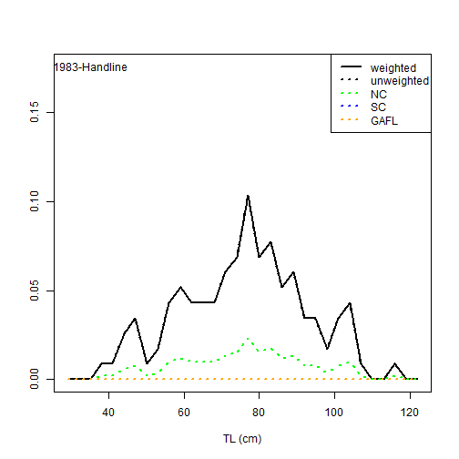

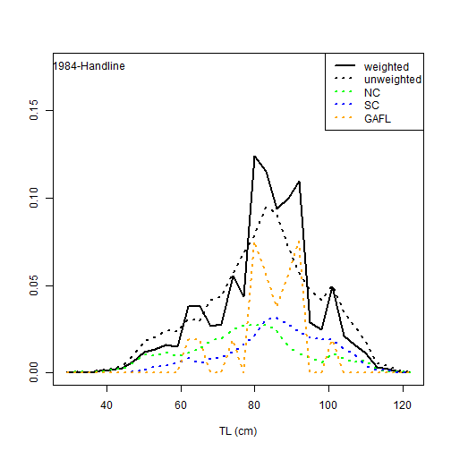

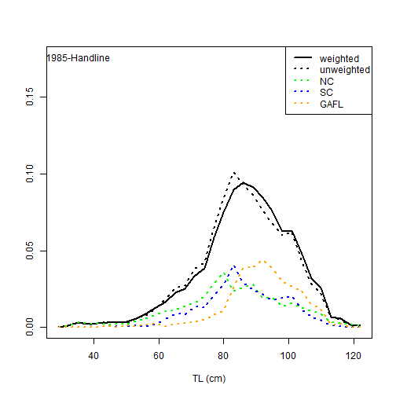

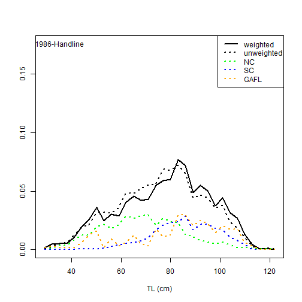

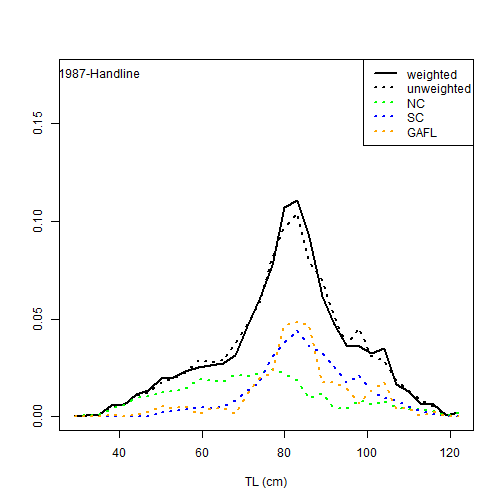

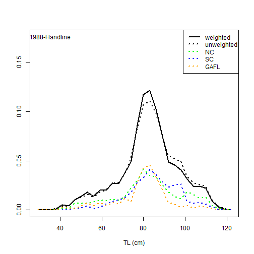

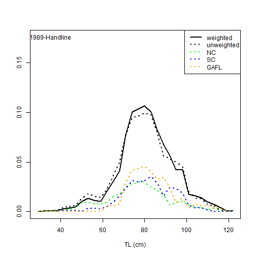

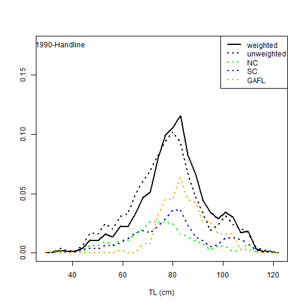

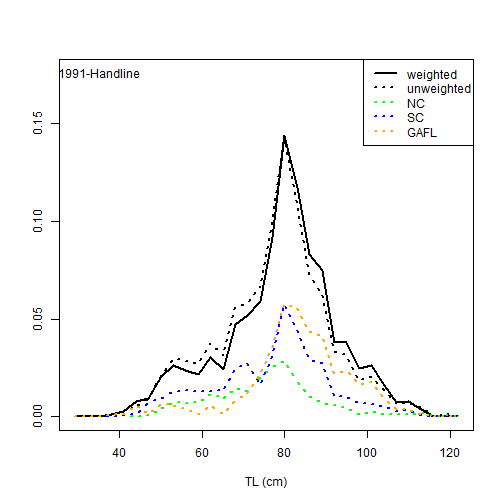

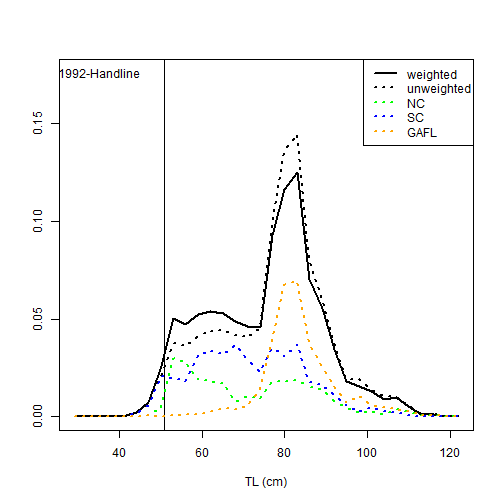

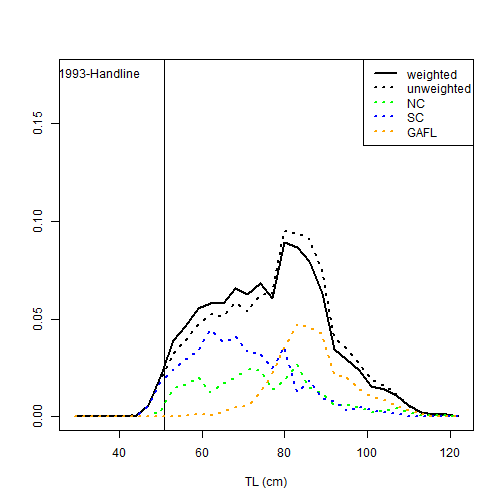

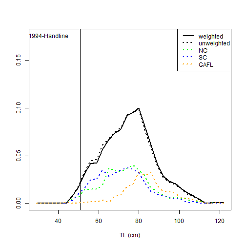

[18 more figures not shown]

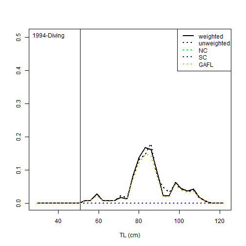

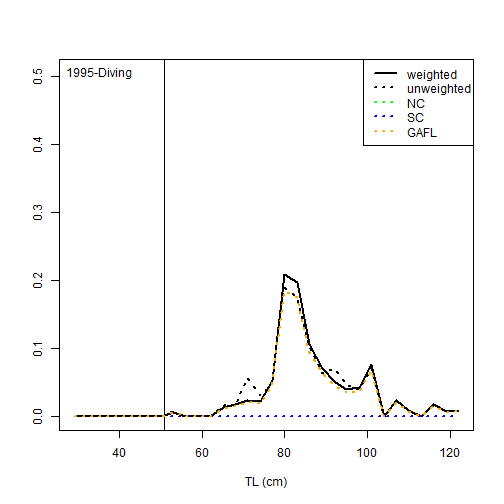

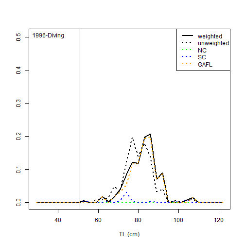

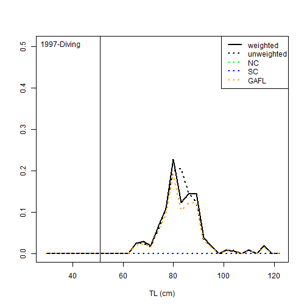

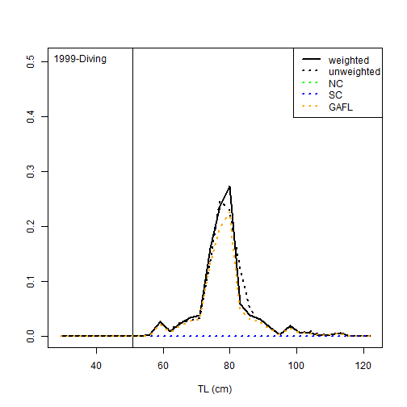

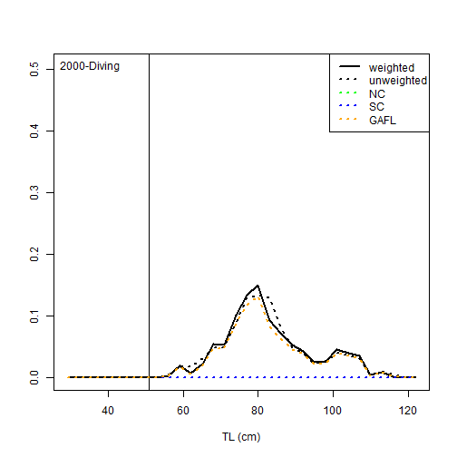

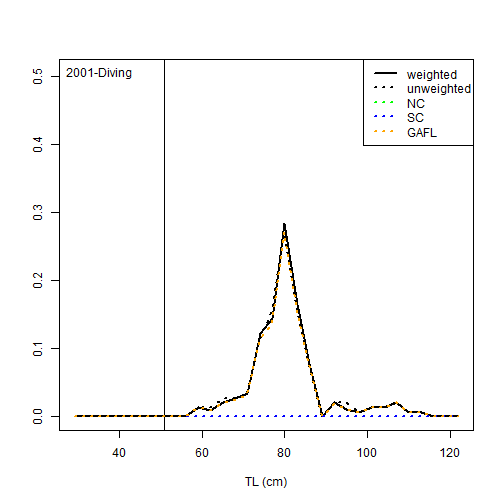

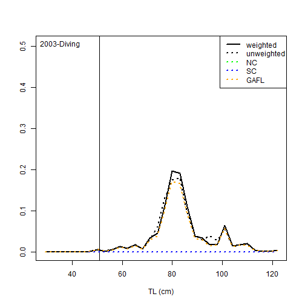

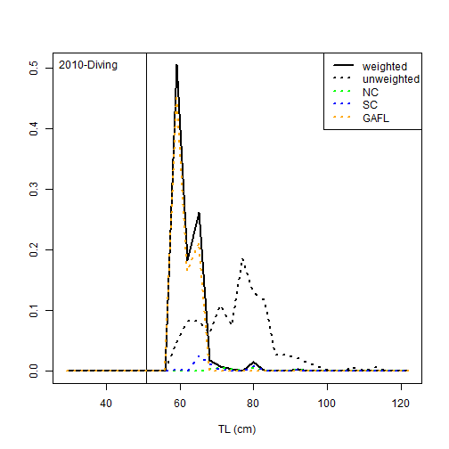

**Age Composition** The commercial handline age compositions were adjusted for bias in sample collections using the Chih(2009) method as in SEDAR 10. Lengths are recorded for each fish sampled for age. A reweighting value (RW) associated with the year (j) and length interval (i) of the age sample was assigned to each age sample by fishery as in the formula:  
\( RW_{ij}=\frac{LC_{ij}}{OL_{ij}/TO_{j}} \)

where \( LC_{ij} \) is the weighted length composition value associated with the year j and length interval i for each aged fish \( OL_{ij} \), is the number of aged samples in length interval i and year j , and \( TO_j \) is the total number of aged samples in year j. This weighting corrects for a potential sampling bias of age samples relative to length samples (Chih, 2009). The numerator in this method differs slightly from the method used by Chih (2009) in that the length composition is weighted by the landings. The commercial diving age compositions were weighted by the state-specific landings in gutted pounds. For some years the weighting had no effect because only one state contributed ages.

**Table 5.** Commercial handline ages, sample size by state.

|  | NC | SC | GaFL | Total |
| --- | --- | --- | --- | --- |
| 1979 | 0 | 144 | 0 | 144 |
| 1980 | 0 | 80 | 0 | 80 |
| 1981 | 0 | 161 | 0 | 161 |
| 1982 | 0 | 24 | 0 | 24 |
| 1983 | 0 | 0 | 6 | 6 |
| 1992 | 1 | 18 | 47 | 66 |
| 1993 | 0 | 22 | 76 | 98 |
| 1994 | 8 | 307 | 29 | 344 |
| 1995 | 22 | 382 | 417 | 821 |
| 1996 | 0 | 17 | 52 | 69 |
| 1997 | 4 | 0 | 111 | 115 |
| 1998 | 0 | 0 | 35 | 35 |
| 1999 | 0 | 0 | 88 | 88 |
| 2000 | 0 | 19 | 51 | 70 |
| 2001 | 0 | 27 | 155 | 182 |
| 2002 | 3 | 14 | 97 | 114 |
| 2003 | 66 | 26 | 91 | 183 |
| 2004 | 356 | 150 | 46 | 552 |
| 2005 | 930 | 678 | 147 | 1755 |
| 2006 | 500 | 346 | 27 | 873 |
| 2007 | 983 | 359 | 72 | 1414 |
| 2008 | 678 | 431 | 3 | 1112 |
| 2009 | 386 | 477 | 73 | 936 |
| 2010 | 532 | 430 | 5 | 967 |
| 2011 | 615 | 392 | 5 | 1012 |
| 2012 | 480 | 216 | 13 | 709 |

**Table 6.** Commercial diving ages, sample size by state.

|  | NC | SC | GAFL | Total |
| --- | --- | --- | --- | --- |
| 1992 | 0 | 0 | 1 | 1 |
| 1994 | 0 | 0 | 47 | 47 |
| 1995 | 0 | 0 | 63 | 63 |
| 1996 | 0 | 0 | 1 | 1 |
| 1997 | 0 | 0 | 54 | 54 |
| 1999 | 0 | 0 | 6 | 6 |
| 2000 | 0 | 0 | 1 | 1 |
| 2001 | 0 | 0 | 4 | 4 |
| 2002 | 0 | 0 | 6 | 6 |
| 2006 | 0 | 6 | 3 | 9 |
| 2007 | 0 | 4 | 2 | 6 |
| 2008 | 0 | 10 | 0 | 10 |
| 2009 | 0 | 29 | 6 | 35 |
| 2010 | 51 | 92 | 5 | 148 |
| 2011 | 18 | 82 | 11 | 111 |
| 2012 | 17 | 5 | 1 | 23 |

**Table 7.** Commercial handline weighted age compostion (years with 47 or more fish).

|  | hl.age.n | 0 | 1 | 2 | 3 | 4 | 5 | 6 | 7 | 8 | 9 | 10 | 11 | 12 | 13 | 14 | 15 | 16 | 17 | 18 | 19 | 20 |
| --- | --- | --- | --- | --- | --- | --- | --- | --- | --- | --- | --- | --- | --- | --- | --- | --- | --- | --- | --- | --- | --- | --- |
| 1979 | 144 | 0.0000000 | 0.0000000 | 0.0000000 | 0.0069444 | 0.0625000 | 0.2291667 | 0.1944444 | 0.1250000 | 0.0833333 | 0.0486111 | 0.0694444 | 0.0555556 | 0.0277778 | 0.0000000 | 0.0000000 | 0.0000000 | 0.0069444 | 0.0208333 | 0.0277778 | 0.0138889 | 0.0277778 |
| 1980 | 80 | 0.0000000 | 0.0000000 | 0.0000000 | 0.0125000 | 0.0125000 | 0.1000000 | 0.2375000 | 0.3750000 | 0.1000000 | 0.0750000 | 0.0250000 | 0.0375000 | 0.0125000 | 0.0000000 | 0.0000000 | 0.0000000 | 0.0000000 | 0.0000000 | 0.0000000 | 0.0000000 | 0.0125000 |
| 1981 | 161 | 0.0000000 | 0.0000000 | 0.0000000 | 0.0434783 | 0.1428571 | 0.0496894 | 0.2173913 | 0.1614907 | 0.2670807 | 0.0372671 | 0.0310559 | 0.0062112 | 0.0124224 | 0.0186335 | 0.0062112 | 0.0000000 | 0.0000000 | 0.0062112 | 0.0000000 | 0.0000000 | 0.0000000 |
| 1992 | 66 | 0.0000000 | 0.0000000 | 0.0302176 | 0.2399130 | 0.2068709 | 0.1050627 | 0.1350626 | 0.2487724 | 0.0213916 | 0.0000000 | 0.0000000 | 0.0127092 | 0.0000000 | 0.0000000 | 0.0000000 | 0.0000000 | 0.0000000 | 0.0000000 | 0.0000000 | 0.0000000 | 0.0000000 |
| 1993 | 98 | 0.0000000 | 0.0000000 | 0.0477298 | 0.1805420 | 0.2328186 | 0.1357235 | 0.1916931 | 0.1180419 | 0.0795835 | 0.0000000 | 0.0000000 | 0.0000000 | 0.0000000 | 0.0000000 | 0.0000000 | 0.0011165 | 0.0127512 | 0.0000000 | 0.0000000 | 0.0000000 | 0.0000000 |
| 1994 | 344 | 0.0000000 | 0.0080271 | 0.0521699 | 0.0672387 | 0.3525411 | 0.2773250 | 0.0851711 | 0.0710286 | 0.0339039 | 0.0305357 | 0.0081639 | 0.0019117 | 0.0000000 | 0.0019117 | 0.0000000 | 0.0019117 | 0.0043299 | 0.0038299 | 0.0000000 | 0.0000000 | 0.0000000 |
| 1995 | 821 | 0.0000000 | 0.0000000 | 0.0109991 | 0.0507359 | 0.0894647 | 0.3102643 | 0.2652971 | 0.0884102 | 0.0793852 | 0.0439809 | 0.0241189 | 0.0133623 | 0.0031462 | 0.0033042 | 0.0049348 | 0.0056145 | 0.0011551 | 0.0012251 | 0.0000000 | 0.0004240 | 0.0041773 |
| 1996 | 69 | 0.0000000 | 0.0000000 | 0.0000000 | 0.0000000 | 0.0000000 | 0.1096466 | 0.4652705 | 0.2937445 | 0.0381201 | 0.0132251 | 0.0000000 | 0.0799931 | 0.0000000 | 0.0000000 | 0.0000000 | 0.0000000 | 0.0000000 | 0.0000000 | 0.0000000 | 0.0000000 | 0.0000000 |
| 1997 | 115 | 0.0000000 | 0.0000000 | 0.0000000 | 0.0000000 | 0.0178364 | 0.0087774 | 0.2043212 | 0.5289744 | 0.1312827 | 0.0217521 | 0.0095289 | 0.0602653 | 0.0000000 | 0.0000000 | 0.0172615 | 0.0000000 | 0.0000000 | 0.0000000 | 0.0000000 | 0.0000000 | 0.0000000 |
| 1999 | 88 | 0.0000000 | 0.0000000 | 0.0135976 | 0.2989472 | 0.0967285 | 0.1954654 | 0.2517439 | 0.0499540 | 0.0267345 | 0.0212332 | 0.0000000 | 0.0174592 | 0.0212799 | 0.0000000 | 0.0000000 | 0.0000000 | 0.0068566 | 0.0000000 | 0.0000000 | 0.0000000 | 0.0000000 |
| 2000 | 70 | 0.0000000 | 0.0000000 | 0.0000000 | 0.1808913 | 0.2055451 | 0.1340224 | 0.2696092 | 0.0698662 | 0.0288736 | 0.0478376 | 0.0430115 | 0.0000000 | 0.0041577 | 0.0078215 | 0.0000000 | 0.0000000 | 0.0000000 | 0.0000000 | 0.0000000 | 0.0000000 | 0.0083639 |
| 2001 | 182 | 0.0000000 | 0.0000000 | 0.0133288 | 0.0891150 | 0.1518693 | 0.1849233 | 0.2030988 | 0.2249262 | 0.0404723 | 0.0124999 | 0.0208138 | 0.0299826 | 0.0144651 | 0.0059765 | 0.0014451 | 0.0014451 | 0.0038926 | 0.0000000 | 0.0000000 | 0.0000000 | 0.0017457 |
| 2002 | 114 | 0.0000000 | 0.0000000 | 0.0000000 | 0.1311261 | 0.1877542 | 0.1585428 | 0.1556847 | 0.1783514 | 0.0912150 | 0.0488764 | 0.0103512 | 0.0136820 | 0.0209113 | 0.0000000 | 0.0000000 | 0.0000000 | 0.0035049 | 0.0000000 | 0.0000000 | 0.0000000 | 0.0000000 |
| 2003 | 183 | 0.0000000 | 0.0000000 | 0.0073433 | 0.1235371 | 0.2367448 | 0.2713698 | 0.1287745 | 0.0678953 | 0.0754314 | 0.0514199 | 0.0082271 | 0.0031953 | 0.0105187 | 0.0041643 | 0.0083358 | 0.0015214 | 0.0000000 | 0.0000000 | 0.0000000 | 0.0000000 | 0.0015214 |
| 2004 | 552 | 0.0000000 | 0.0000000 | 0.0034441 | 0.1276208 | 0.2420838 | 0.2532020 | 0.1980198 | 0.0375074 | 0.0667108 | 0.0120441 | 0.0184790 | 0.0176056 | 0.0064622 | 0.0041193 | 0.0063674 | 0.0000000 | 0.0000000 | 0.0014301 | 0.0000000 | 0.0000000 | 0.0049035 |
| 2005 | 1755 | 0.0000000 | 0.0000000 | 0.0026946 | 0.0543973 | 0.2916880 | 0.2812335 | 0.1664868 | 0.1082269 | 0.0265115 | 0.0214907 | 0.0167170 | 0.0126721 | 0.0088553 | 0.0033314 | 0.0007362 | 0.0021258 | 0.0006422 | 0.0007835 | 0.0000000 | 0.0002504 | 0.0011567 |
| 2006 | 873 | 0.0000000 | 0.0000000 | 0.0054132 | 0.0847043 | 0.2156252 | 0.3745760 | 0.1488503 | 0.0673406 | 0.0463412 | 0.0078141 | 0.0255229 | 0.0076825 | 0.0026104 | 0.0089825 | 0.0014963 | 0.0018277 | 0.0003313 | 0.0008816 | 0.0000000 | 0.0000000 | 0.0000000 |
| 2007 | 1414 | 0.0000000 | 0.0000000 | 0.0031001 | 0.0401432 | 0.1416303 | 0.2369775 | 0.3195717 | 0.1364561 | 0.0616849 | 0.0349612 | 0.0056160 | 0.0027395 | 0.0074328 | 0.0051014 | 0.0000000 | 0.0030866 | 0.0011765 | 0.0003222 | 0.0000000 | 0.0000000 | 0.0000000 |
| 2008 | 1112 | 0.0000000 | 0.0000000 | 0.0075100 | 0.0680717 | 0.1546926 | 0.2742716 | 0.2316476 | 0.1527601 | 0.0424583 | 0.0326894 | 0.0119942 | 0.0091048 | 0.0041824 | 0.0035840 | 0.0018071 | 0.0038041 | 0.0004188 | 0.0005987 | 0.0000000 | 0.0004045 | 0.0000000 |
| 2009 | 936 | 0.0000000 | 0.0000000 | 0.0227995 | 0.1230712 | 0.1782103 | 0.1916459 | 0.1868133 | 0.1369741 | 0.0684083 | 0.0455743 | 0.0165012 | 0.0115387 | 0.0079766 | 0.0025238 | 0.0029390 | 0.0017635 | 0.0010110 | 0.0008964 | 0.0009704 | 0.0001978 | 0.0001845 |
| 2010 | 967 | 0.0000000 | 0.0000000 | 0.0144820 | 0.0825245 | 0.3039500 | 0.2306122 | 0.1867546 | 0.0958978 | 0.0493078 | 0.0184035 | 0.0058868 | 0.0027205 | 0.0024568 | 0.0016624 | 0.0007006 | 0.0020975 | 0.0004413 | 0.0014012 | 0.0000000 | 0.0000000 | 0.0007006 |
| 2011 | 1012 | 0.0000000 | 0.0000000 | 0.0032326 | 0.0779895 | 0.2624390 | 0.3553212 | 0.1657232 | 0.0806772 | 0.0146771 | 0.0134766 | 0.0187695 | 0.0010740 | 0.0014124 | 0.0000000 | 0.0000000 | 0.0052076 | 0.0000000 | 0.0000000 | 0.0000000 | 0.0000000 | 0.0000000 |
| 2012 | 709 | 0.0000000 | 0.0006199 | 0.0018454 | 0.0517244 | 0.2730293 | 0.2281913 | 0.2042716 | 0.0945867 | 0.0309646 | 0.0440709 | 0.0226503 | 0.0351344 | 0.0046640 | 0.0007318 | 0.0029272 | 0.0000000 | 0.0000000 | 0.0000000 | 0.0000000 | 0.0000000 | 0.0045882 |

|  | dv.age.n | 0 | 1 | 2 | 3 | 4 | 5 | 6 | 7 | 8 | 9 | 10 | 11 | 12 | 13 | 14 | 15 | 16 | 17 | 18 | 19 | 20 |
| --- | --- | --- | --- | --- | --- | --- | --- | --- | --- | --- | --- | --- | --- | --- | --- | --- | --- | --- | --- | --- | --- | --- |
| 1995 | 63 | 0.0000000 | 0.0000000 | 0.0158730 | 0.0158730 | 0.0476190 | 0.0000000 | 0.4603175 | 0.3015873 | 0.1111111 | 0.0317460 | 0.0158730 | 0.0000000 | 0.0000000 | 0.0000000 | 0.0000000 | 0.0000000 | 0.0000000 | 0.0000000 | 0.0000000 | 0.0000000 | 0.0000000 |
| 1997 | 54 | 0.0000000 | 0.0000000 | 0.0185185 | 0.0185185 | 0.1851852 | 0.0555556 | 0.0925926 | 0.5370370 | 0.0925926 | 0.0000000 | 0.0000000 | 0.0000000 | 0.0000000 | 0.0000000 | 0.0000000 | 0.0000000 | 0.0000000 | 0.0000000 | 0.0000000 | 0.0000000 | 0.0000000 |
| 2010 | 148 | 0.0000000 | 0.0000000 | 0.1557779 | 0.6564213 | 0.0668278 | 0.0575876 | 0.0421105 | 0.0157077 | 0.0043428 | 0.0000000 | 0.0000000 | 0.0000000 | 0.0000000 | 0.0000000 | 0.0012243 | 0.0000000 | 0.0000000 | 0.0000000 | 0.0000000 | 0.0000000 | 0.0000000 |
| 2011 | 111 | 0.0000000 | 0.0000000 | 0.0600457 | 0.1028362 | 0.4055680 | 0.3677610 | 0.0519340 | 0.0039517 | 0.0039517 | 0.0039517 | 0.0000000 | 0.0000000 | 0.0000000 | 0.0000000 | 0.0000000 | 0.0000000 | 0.0000000 | 0.0000000 | 0.0000000 | 0.0000000 | 0.0000000 |

**Figure 3.** Commercial handline weighted Age composition. (1979-1982 unweighted due to lack of length data, years with greater than 46 fish)

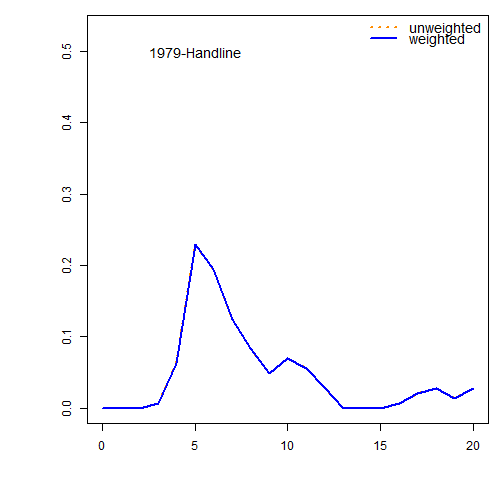

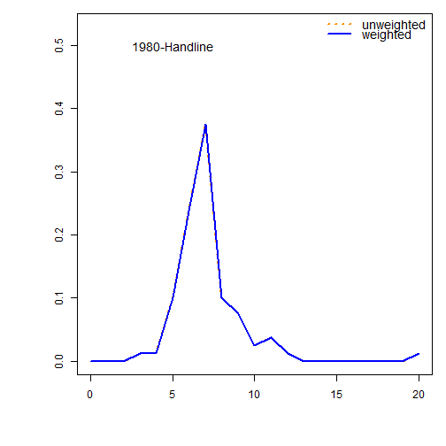

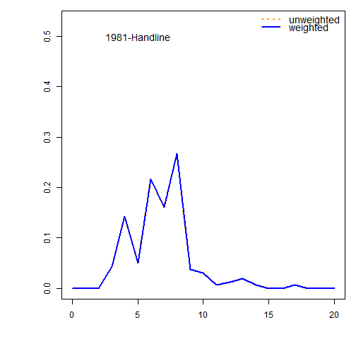

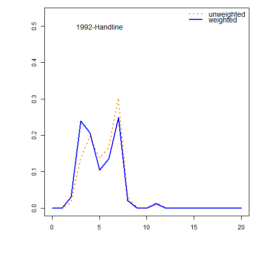

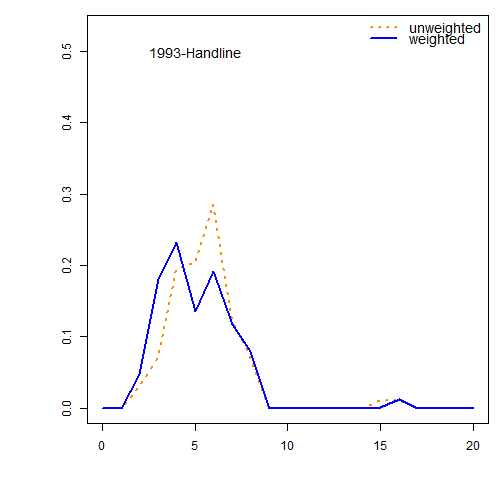

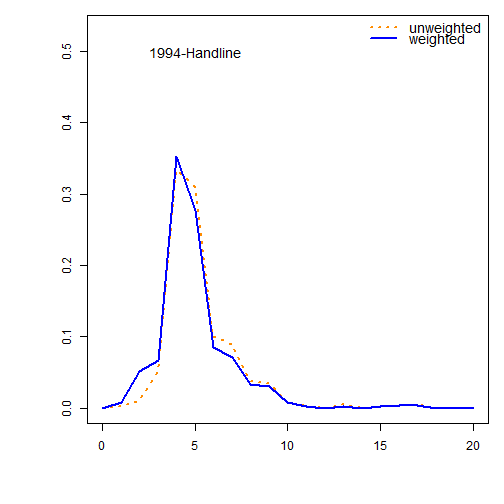

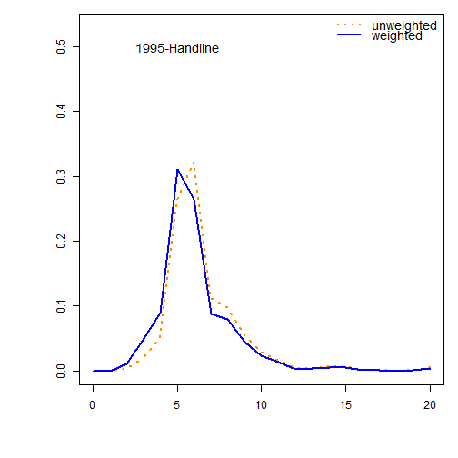

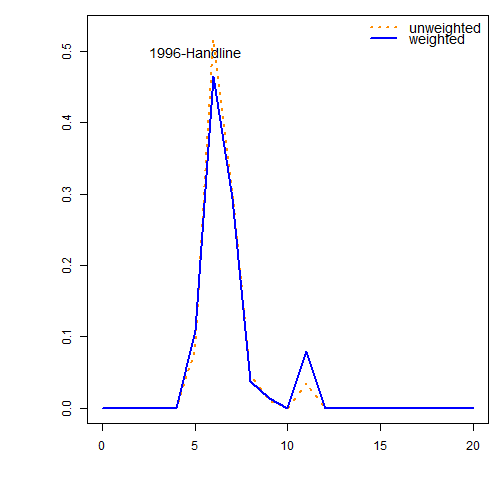

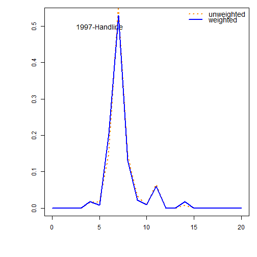

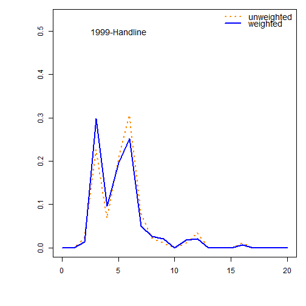

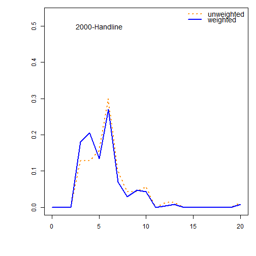

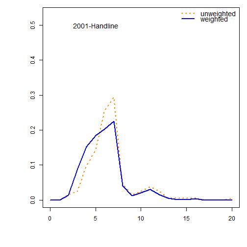

[11 more figures not shown]

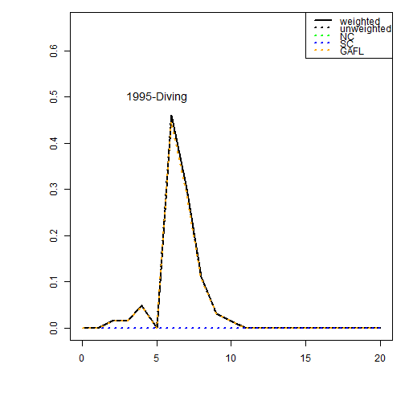

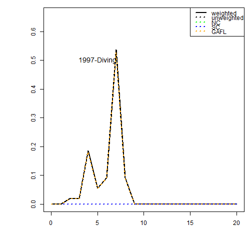

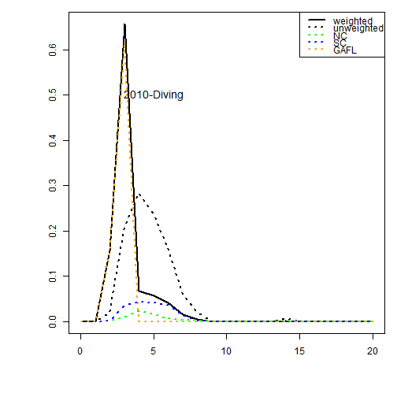

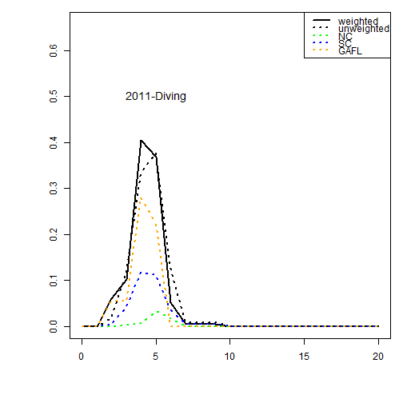